# Modeling

Shikhar Khanna

14/07/2019

```r
data = read.csv("day.csv")
data$season = as.factor(data$season)
levels(data$season) <- c("spring", "summer", "fall", "winter")

data$holiday = as.factor(data$holiday)
levels(data$holiday) = c("no", "yes")

data$workingday = as.factor(data$workingday)
levels(data$workingday) = c("no", "yes")

data$weathersit = as.factor(data$weathersit)
levels(data$weathersit) = c("Clearish", "Misty", "LightPrecip")

data$weekday = as.factor(data$weekday)
levels(data$weekday) = c("Sun", "Mon", "Tue", "Wed", "Thu", "Fri", "Sat")

data$mnth = as.factor(data$mnth)
levels(data$mnth) = c("Jan", "Feb", "Mar", "Apr", "May", "Jun", "Jul", "Aug", "Sep", "Oct", "Nov", "Dec")

data$yr = as.factor(data$yr)
levels(data$yr) = c("2011", "2012")


data=data[,c(-1,-2,-14,-15)]
```

Lets separate numerical and categorical variable

```r
numerical <- unlist(lapply(data, is.numeric)) # contains bolean value against each variable indicating wether that variable is a numeric or not
```

Lets first start by using only the numerical predictors to model the target variable

```r
data_numerical= data[, numerical] # get the target and all the numerical columns
bike_mod_num = lm(cnt ~ ., data = data_numerical)
summary(bike_mod_num)[["coefficients"]]
```

```
##              Estimate Std. Error    t value     Pr(>|t|)
## (Intercept)  3860.368   355.3890 10.8623754 1.426590e-25
## temp         2111.814  2282.1976  0.9253422 3.550954e-01
## atemp        5139.152  2576.9972  1.9942406 4.649933e-02
## hum         -3149.110   383.9943 -8.2009286 1.081541e-15
## windspeed   -4528.675   721.0854 -6.2803588 5.815379e-10
```

```r
summary(bike_mod_num)[["adj.r.squared"]]
```

```
## [1] 0.460878
```

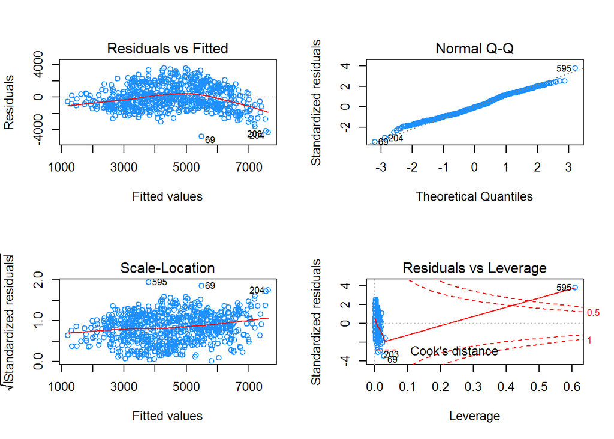

```r
par(mfrow = c(2, 2))
plot(bike_mod_num,col = 'dodgerblue')
```

*Findings:*

- The above results show that the temp is not very significant predictor as it has a high p value , this can be attributed to the fact that temp and atemp were highly correlated as we saw in the EDA and may be because of that, the effect of one gets eaten up by other.
- The Multiple R-squared is quite low and does not discount for a good model.
- The Fitted vs Residual plot shows a bit of non linear trend and the leverage plot also highlights some outliers.
- We can expect there results to improve as we start using categorical columns with dummy variables.

Lets now use both the categorical and numerical predictor and see if we get some lift in the models performance.

```r
bike_mod_all=lm(cnt~., data=data)
summary(bike_mod_all)[["coefficients"]]
```

```
##                          Estimate Std. Error     t value      Pr(>|t|)
## (Intercept)            1485.84392  239.74649  6.19756289  9.774832e-10
## seasonsummer            884.71081  179.49244  4.92895861  1.032402e-06
## seasonfall              832.70222  213.12943  3.90702600  1.024766e-04
## seasonwinter           1575.35064  181.00081  8.70355585  2.279871e-17
## yr2012                 2019.73543   58.22037 34.69121792 2.294966e-154
## mnthFeb                 131.02513  143.77618  0.91131318  3.624432e-01
## mnthMar                 542.82773  165.43291  3.28125608  1.084575e-03
## mnthApr                 451.16562  247.56686  1.82239911  6.881974e-02
## mnthMay                 735.50548  267.62770  2.74824120  6.145473e-03
## mnthJun                 515.40479  282.41068  1.82501876  6.842301e-02
## mnthJul                  30.79664  313.82098  0.09813442  9.218536e-01
## mnthAug                 444.94895  303.16514  1.46767848  1.426395e-01
## mnthSep                1004.17283  265.12279  3.78757646  1.651562e-04
## mnthOct                 519.67428  241.55359  2.15138294  3.178651e-02
## mnthNov                -116.69328  230.77620 -0.50565560  6.132572e-01
## mnthDec                 -89.59150  182.21449 -0.49168152  6.230982e-01
## holidayyes             -589.69719  180.36226 -3.26951542  1.129889e-03
## weekdayMon              212.05386  109.49409  1.93666948  5.318673e-02
## weekdayTue              309.52763  107.13399  2.88916364  3.981733e-03
## weekdayWed              381.35742  107.47774  3.54824567  4.136266e-04
## weekdayThu              386.34297  107.52858  3.59293290  3.498183e-04
## weekdayFri              436.98377  107.43933  4.06726072  5.296026e-05
## weekdaySat              440.45884  106.56233  4.13334457  4.007227e-05
## weathersitMisty        -462.53813   77.08692 -6.00021534  3.156422e-09
## weathersitLightPrecip -1965.08654  197.05173 -9.97244020  5.386219e-22
## temp                   2855.01072 1398.15623  2.04198262  4.152649e-02
## atemp                  1786.15738 1462.11957  1.22162196  2.222607e-01
## hum                   -1535.46844  292.44826 -5.25039352  2.013660e-07
## windspeed             -2823.29668  414.55208 -6.81047529  2.091887e-11
```

```r
summary(bike_mod_all)[["adj.r.squared"]]
```

```
## [1] 0.8423198
```

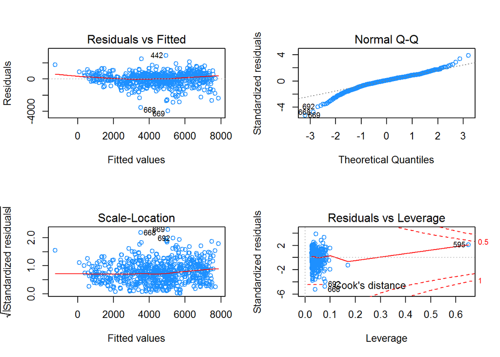

```r
par(mfrow = c(2, 2))
plot(bike_mod_all,col = 'dodgerblue')
```

*Findings:*

- Looks like this definitely helped in lifting the performance of the model as we now have a higher value of adjusted r-squared, but this comes at the cost at creating a complex model and the results show that not all variables are significant.
- The residuals seems to have lost there normality.
- The fitted vs residual plot shows a non linear trend and we also see presence of some extreme outlier.
- The leverage plot also indicates presence of some outliers which we might have to check on as we go down the analysis.

Based upon the results it would be good to test for the significance for few of the categorical variables which are listed below:

- Month
- Week Day
- Working Day

```r
bike_mod_w_month=lm(cnt~.-mnth, data=data) # model without month
bike_mod_w_weekday=lm(cnt~.-weekday, data=data) # model without weekday
bike_mod_w_workingday=lm(cnt~.-workingday, data=data) # model without workingday
anova(bike_mod_w_month,bike_mod_w_weekday,bike_mod_w_workingday,bike_mod_all)
```

```
## Analysis of Variance Table
##
## Model 1: cnt ~ (season + yr + mnth + holiday + weekday + workingday +
##     weathersit + temp + atemp + hum + windspeed) - mnth
## Model 2: cnt ~ (season + yr + mnth + holiday + weekday + workingday +
##     weathersit + temp + atemp + hum + windspeed) - weekday
## Model 3: cnt ~ (season + yr + mnth + holiday + weekday + workingday +
##     weathersit + temp + atemp + hum + windspeed) - workingday
## Model 4: cnt ~ season + yr + mnth + holiday + weekday + workingday + weathersit +
##     temp + atemp + hum + windspeed
##   Res.Df       RSS Df Sum of Sq       F    Pr(>F)
## 1    713 472452877
## 2    707 428442679  6  44010198 12.3957 2.683e-13 ***
## 3    702 415401688  5  13040991  4.4077 0.0005852 ***
## 4    702 415401688  0         0
## ---
## Signif. codes:  0 '***' 0.001 '**' 0.01 '*' 0.05 '.' 0.1 ' ' 1
```

*Findings:*

- The test shows that month, weekday are significant predictors hence we cant rule them out.Even though the month variable is statistically significant , it might be that just few levels are useful and rest of them does not help. We will use model selection schemes later to find that out.
- Acoording to test results working day variable seems to be non significant and we can rule out this variable.

Lets fit the model again, without the working day variable.

```r
data_2= data[,c(-6)]
bike_mod_all_2=lm(cnt~., data=data_2)
summary(bike_mod_all_2)[["adj.r.squared"]]
```

```
## [1] 0.8423198
```

This looks like a good starting point. We can now get started with identifying multi collinearity in the model, we will start looking at VIF to understand if we have multi collinearity.

```r
library(faraway)
vif(bike_mod_all_2)
```

```
##          seasonsummer            seasonfall          seasonwinter
##              7.496334             10.720030              7.455172
##                yr2012               mnthFeb               mnthMar
##              1.046828              1.835947              2.624298
##               mnthApr               mnthMay               mnthJun
##              5.704404              6.868018              7.423137
##               mnthJul               mnthAug               mnthSep
##              9.443506              8.813082              6.542133
##               mnthOct               mnthNov               mnthDec
##              5.594951              4.956867              3.183722
##            holidayyes            weekdayMon            weekdayTue
##              1.121296              1.821782              1.730242
##            weekdayWed            weekdayThu            weekdayFri
##              1.741363              1.743011              1.740119
##            weekdaySat       weathersitMisty weathersitLightPrecip
##              1.725530              1.642310              1.338411
##                  temp                 atemp                   hum
##             80.806689             70.036722              2.140362
##             windspeed
##              1.273296
```

As suspected before temp and atemp has high level of collinearity.Lets get the partial correlation coefficient for the temp variable and see if its useful for the model

```r
temp_model=lm(temp~.-cnt, data=data_2)
cor(resid(bike_mod_all_2), resid(temp_model))
```

```
## [1] 2.286334e-16
```

Since the value is quite small , we can consider removing temp variable from the model. Although multi collinearity might not have much impact on the prediction but it does have an impact on the inference of the model.

```r
data_3= data[,c(-6, -8)]
bike_mod_all_3=lm(cnt~., data=data_3)
summary(bike_mod_all_3)[["adj.r.squared"]]
```

```
## [1] 0.8416089
```

Next we would want to also check for potential outliers , we have 3 ways of doing it :

- Leverage
- Standard Residual
- Cooks distance

We will be using cooks distance to identify any such outlier and see the effect of it on the model.

First lets calculate no of observation flagged by cooks distance:

```r
sum(cooks.distance(bike_mod_all_3) > 4 / length(cooks.distance(bike_mod_all_3)))
```

```
## [1] 42
```

Next we can consider fitting a model after removing these observation

```r
cokks_distance = cooks.distance(bike_mod_all_3)
bike_mod_all_4 = lm(cnt ~.,
                    data = data_3,
                    subset = cokks_distance <= 4 / length(cokks_distance))
summary(bike_mod_all_4)[["adj.r.squared"]]
```

```
## [1] 0.9093198
```

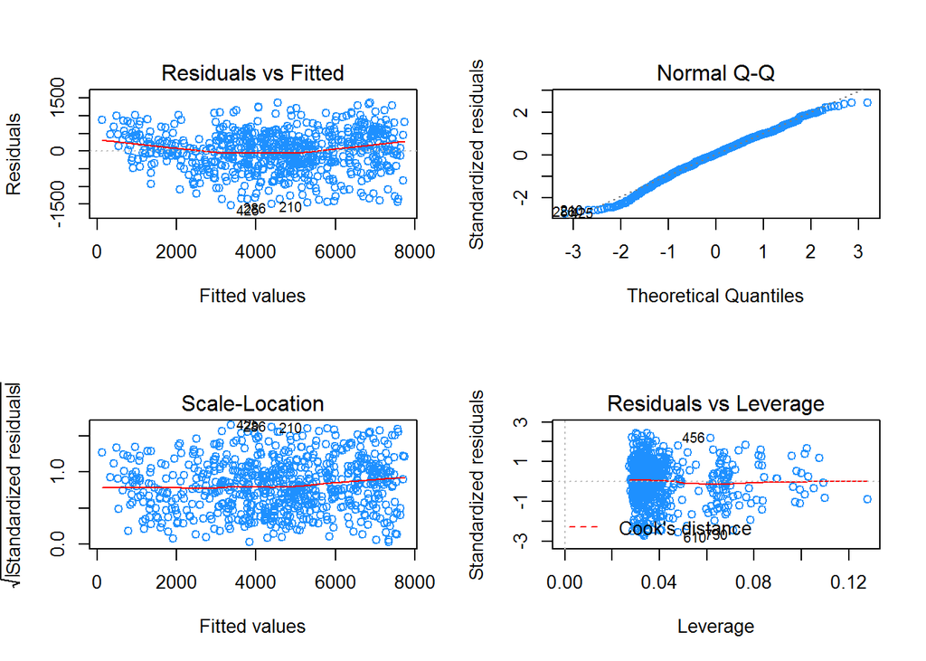

```r
par(mfrow = c(2, 2))
plot(bike_mod_all_4,col = 'dodgerblue')
```

*Findings:*

- Removing these outliers helped get a lift in the adjusted r-squared from 84% to 90% which is a good thing.
- The residuals start looking more normal.
- The residual vs fitted plot still show some non linear pattern which indicates to the fact to try out higher order terms.
- The leverage plot looks much neater.